# Intro to R - preliminaries

## RStudio

We will be using an RStudio which is an interface which accompanies R. It does mainly the same stuff as the Graphical User Interface (GUI) which comes with R but is more user friendly and helps you out with some things. We will be using RStudio, but if you learn this you will still know how to use the GUI in R.RStudio can be downloaded from the program website https://www.rstudio.com/. You can download the latest version of R studio. Make also sure that you also install a stable version of R. https://cran.stat.auckland.ac.nz/

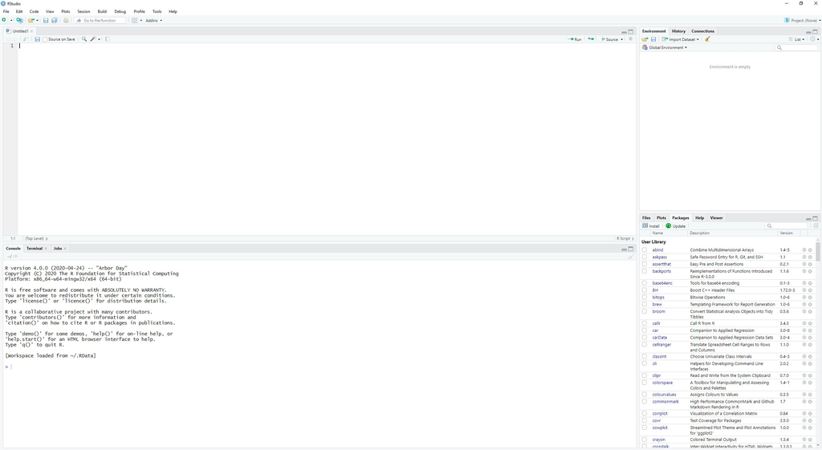

```r
knitr::include_graphics("E:\\Dropbox (Personal)\\Auckland\\Teaching\\sem 1 2021\\771\\Labs\\lab1\\figures\\rstudio.JPG")
```

To open a new script editor, go to File>New file>R Script

## What do we have in this interface:

### Console (bottom left)

This is the ‘brains’ of R – if you type code in here and press return, the code will be actioned. This is where it will also tell you in red writing what you have done wrong! When you are first learning R (and beyond!), you will get things wrong all the time. Don’t worry – most of the time this is down to minor typos in your script or code.

### Script editor (top left)

This is where you can work on your code without it being actioned. When you are ready to action the code, either highlight the code or click at the end of the line and click Run. If the code is not highlighted RStudio will only run that line. If you want to run all the code that is in the script editor document together, you can click Source.

### Tabs on the top right:

### Environment

This contains the information (such as objects) that you currently have saved in your memory. If one of your objects does not appear here, R will not be able to use it. You can also remind yourself of all the objects you have created by typing ls().

### History

This records all the code you have used in that particular session. Tabs on the lower right:

### Files

This is just an overview of your files.

### Plots

This is where your graphs will appear when you start doing them.

### Packages

These are additional packages which you may need to load later on which contain built-in code.

### Help

This is where the help files appear when you type help() or ??

### Viewer

This bit displays previews of some more advanced stuff you may use later on.

### Objects

An object in R is anything that you can work with. It can be a dataset, a function, a name or anything else. You use name <- to assign a name to this object. From then on, you use this name when working in R.

## Handy hints

By convention, R files generally have the extension .Rda. R scripts have the extension .R

Warning: R will overwrite objects and files of the same name if you call them the same thing. It will not warn you before it does this.

There are also lots of ways of doing the same things in R – sometimes it is just personal preference.

## Commands and comments

Commands are separated either by a semi-colon (‘;’), or by a newline. Elementary commands can be grouped together into one compound expression by braces (‘{’ and ‘}’). Comments can be put almost anywhere, starting with a hash mark (‘#’), everything to the end of the line is a comment.

If a command is not complete at the end of a line, R will give a different prompt, by default ‘+’ on second and subsequent lines and continue to read input until the command is syntactically complete.

If you want to repeat or revise some previous commands, you can use the vertical arrow keys on the keyboard to scroll between previous entries in the R Console.

Add hashes to add comments before your text. The text will turn green if this has worked. This means that R will not treat this as code. You need to do this on every line. Anything in black is treated as code.

Remember to keep your code in R clean and easily readable. You should always start with a brief comment on what the code is about, who created and possibly when.

```r
#Training
#Learning how to use Rstudio, opening files, writing scripts and some data mining.
#Your name
x <- 1:3
y <- -1:-3
#or by using a semicolon
x <- 1:3; y <- -1:-3
```

## Common typos

• R is CASE SENSITIVE – if you get an error message check there are no capitals where there should be lowercase letters and vice versa • Check your brackets match up

• You may use <- and = exchangeable in some cases

## Help information

R has many, many commands and no-one knows them all! You will get to learn the basics and they will come naturally to you, but there is plenty help out there if you get stuck. In particular, online forums are a good way to get different explanations of how to do some tricky stuff.

• Usually, help is available in HTML format by running.

• help.start () will open some useful reference manuals

• help(thing.I.need.help.with) brings back help notes on a particular function. For each function, there are many different options you can add to it and the help section will explain these

• ??thing.I.need.help.with searches on a text string in case there are no help packages set up

```r
help.start()
##To get more information on any specific named function, for example plot(), the command is

help(plot)

##Or, you can simply use
?plot

##The examples on a help topic, such as plot, can normally be run by
example(plot)
```

## R resources

There is an extensive amount of resources about R on the internet, just Google “R books” and you will find plenty. Here is a list of some helpful materials: • RStudio cheat sheets (multilingual) https://www.rstudio.com/resources/cheatsheets/ • An Introduction to R http://cran.r-project.org/manuals.html • R for Beginners https://cran.r-project.org/doc/contrib/Paradis-rdebuts_en.pdf • Cookbook for R http://www.cookbook-r.com/ • R in Action https://www.manning.com/books/r-in-action-second-edition and the related Quick-R website http://www.statmethods.net • Advanced R http://adv-r.had.co.nz/ by Hadley Wickham, the Chief Scientist at RStudio

## Packages

All R functions and datasets are stored in packages. Only when a package is loaded are its contents available. To see which packages are installed at your site, issue the command

```r
library()
```

To load a particular package (e.g., stats), use a command like

```r
library(stats)
```

Packages are often inter-dependent, and loading one may cause others to be automatically loaded.

### Namespaces

All packages have namespaces, and have since R 2.14.0. Namespaces do three things:

• they allow the package writer to hide functions and data that are meant only for internal use, • they prevent functions from breaking when a user (or other package writer) picks a name that clashes with one in the package, and • they provide a way to refer to an object within a particular package.

For example, t() is the transpose function in R, but users might define their own function named t. Namespaces prevent the user’s definition from taking precedence, and breaking every function that tries to transpose a matrix.

The basic R functions can be expanded by installing additional “packages”, for example:

```r
#Install / download the package ggplot2
install.packages("ggplot2")
#Loads the package which make the functions contained within it available to use
library(ggplot2)
```

Sometimes it is useful to store the code you are writing for later reuse. This is quite simple because R code can be stored in text files; these are typically given the extension .R. These files can also be opened within R studio, and can be created using the file menu. Open .R files are shown in the top left window. By highlighting code within this window and clicking the “Run” button, the commands are sent to the console and run. This is a good way of saving your work!. There are also other types of files which can be opened or created within R-Studio that produce an excellent way to embed analysis and interpretation in a single document. These are called Rmarkdown files. We will have a separate little tutoria focused specifically on them. There are also some great tutorials available here: rmarkdown.rstudio.com/.

Before starting any R analysis it is useful to see where your working directory has been set. This is the default location where R looks for files to read in or write out (We will discuss it in detail :). You can check your working directory using the getwd() function:

```r
getwd()
```

You can also set this by entering a directory location using the setwd() function:

```r
setwd("CHANGE TO FILE PATH")
```

[figure not shown]

```r
knitr::include_graphics("E:\\Dropbox (Personal)\\Auckland\\Teaching\\sem 1 2021\\771\\Labs\\lab1\\figures\\setwd.png")
```

##Creating Objects and their classes

Objects in R are a way of storing values which can be returned for reuse later in your code. These use the “<-” symbol. For example:

```r
a <- 5
b <- 10
a + b
```

```
## [1] 15
```

There are a range of different data types which include: numeric, integer, logical, character and complex (which isn’t covered here). The following code illustrates how these variables can be assigned and their values checked. Also - note that we can add comments to our code using the “#” symbol - this is not run by the R compiler.

```r
#Creates a variable called z, which stores a numeric value
z <- 54.8
class(z) #class function returns the class of the object
```

```
## [1] "numeric"
```

```r
#Creates a variable called y, which stores a integer value
y <- 51
y #prints the value of a variable
```

```
## [1] 51
```

```r
#Creates variables c and d, then q which stores the output of the logical query
c <- 5
d <- 2
q <- c < d #stores a true / false if d is greater than c
q
```

```
## [1] FALSE
```

```r
#Creates a variable called s, which stores a character value
s <- "Hello"
is.character(s) #a function to check if an object is a character - returns true or false
```

```
## [1] TRUE
```

### Converting Between Object Classes

This part comes from Intro tutorial prepared by Alex Singelton.

Sometimes it is necessary to convert between different object types, for example, numeric to character or vice versa.

```r
u <- 4 #creates a numeric object
as.character(u) #Converts the variable to a character, which is visible in the printed result as the number is surrounded by a double quote
```

```
## [1] "4"
```

```r
i <- "1" #creates a character object
as.numeric(i) #Converts the character object to a numeric
```

```
## [1] 1
```

### Vectors

It is also possible to store multiple values of the same data type within an object which are called vectors. These are created using the “c()” function. For example:

```r
# creates a numeric vector
v_1 <- c(2,3,5,6,7,8,9)
v_2 <- c(4,7,9,12,11,1,3) # creates a second numeric vector
v_1 - v_2 # vectors can be used as variables with operators - this calculates the difference between v_1 and v_2
```

```
## [1] -2 -4 -4 -6 -4  7  6
```

```r
v_1 * 10 #vectors can also be combined with constants
```

```
## [1] 20 30 50 60 70 80 90
```

```r
# creates a character string vector
v_3 <- c("I","like","R","it","is","fun")
```

It is also possible to extract an element of a vector using an index.

```r
#Returns the 4th element of the vector v_3
v_3[4]
```

```
## [1] "it"
```

A further type of vector which includes mixed objects types are called “lists”.

```r
#Create a mixed list containing two characters, two numbers and a list
v_4 <- list("A", "B", 4, 5, v_1)
```

Accessing content of the list happens in the same way as a vector.

```r
# Return the second and fourth element of the list
v_4[c(2,4)]
```

```
## [[1]]
## [1] "B"
##
## [[2]]
## [1] 5
```

However, in order to reference part of the list directly a double square bracket is needed. This can also be combined with a second square bracket to pull elements of nested list.

```r
#Return the fifth element of the list directly
v_4[[5]]
```

```
## [1] 2 3 5 6 7 8 9
```

```r
#Return the fifth element of the list directly; then the 3rd and fourth elements of this list
v_4[[5]][c(3,4)]
```

```
## [1] 5 6
```

### Factors

Factors are a further object type that R uses to manage nominal and ordinal values. These can be created from vectors; for example:

```r
#Create a nominal vector

n <- c("London","New York","London","New York","Shanghai","Chicago","Chicago")
is.character(n)
```

```
## [1] TRUE
```

```r
o <- factor(n)
# The object o is no longer a character vector
is.character(o)
```

```
## [1] FALSE
```

```r
is.factor(o)
```

```
## [1] TRUE
```

It is also possible to check the “levels” used in a factor object; and can also be summarised using the summary function.

```r
levels(o) #returns the levels used int he factor
```

```
## [1] "Chicago"  "London"   "New York" "Shanghai"
```

```r
summary(o) #returns the count items within the vector coded by each level
```

```
##  Chicago   London New York Shanghai
##        2        2        2        1
```

Ordinal variables have a slightly different specification; for example:

```r
responses <- c("Very Unhappy", "Unhappy","Very Unhappy", "Unhappy","Very Unhappy", "Unhappy", "Fine", "Happy", "Very Happy", "Fine", "Happy", "Very Happy", "Fine", "Happy", "Very Happy")

p <- factor(responses, levels=c("Very Unhappy", "Unhappy", "Fine", "Happy", "Very Happy"), ordered=TRUE)
table(p) #Works in the same way as summary
```

```
## p
## Very Unhappy      Unhappy         Fine        Happy   Very Happy
##            3            3            3            3            3
```

## Working with variables

There are also a series of functions within base R that can work with variables or vectors. Details about how to use any R function can be found by using the “?” command. For example, in the case of “is.character”:

```r
?is.character()
```

```
## starting httpd help server ... done
```

### Character Functions

```r
#Character functions
length(v_3) #Return the length of a string
```

```
## [1] 6
```

```r
#Find out how many characters each element of a string contains
nchar(v_3)
```

```
## [1] 1 4 1 2 2 3
```

```r
#Create a new variable from the 2nd element of the vector v_3
k <- v_3[2]

#Use the substring function to extract characters between the 2-3rd characters
substr(k,2,3)
```

```
## [1] "ik"
```

```r
# Substitute an element of a string
u <- "ABCDEFGHIJKLMNOPQRSTUVWXYZ"
gsub("A","Z",u) #Replace the letter A with Z
```

```
## [1] "ZBCDEFGHIJKLMNOPQRSTUVWXYZ"
```

```r
#Find the position of a string within a vector
grep("R",v_3)
```

```
## [1] 3
```

```r
#Split a string on a particular character; returns a two element vector
u_2 <- strsplit(u,"D")
u_2[1] #prints the first element of the vector
```

```
## [[1]]
## [1] "ABC"                    "EFGHIJKLMNOPQRSTUVWXYZ"
```

```r
#Concatenate strings
paste("A","B")#combines the two strings with a space separating
```

```
## [1] "A B"
```

```r
paste0("A","B")#combines the two strings without a space separating
```

```
## [1] "AB"
```

```r
#Change the case of a string
tolower(u)
```

```
## [1] "abcdefghijklmnopqrstuvwxyz"
```

```r
toupper("hello")
```

```
## [1] "HELLO"
```

###Numeric Functions

```r
#Create a 100 random numbers
h <- runif(100, 0.0, 1.0)

# Min
min(h)
```

```
## [1] 0.01168258
```

```r
# Max
max(h)
```

```
## [1] 0.9969923
```

```r
# Standard Deviation
sd(h)
```

```
## [1] 0.2833376
```

```r
# Mean
mean(h)
```

```
## [1] 0.5091918
```

```r
# Median
median(h)
```

```
## [1] 0.4861719
```

```r
# Range
range(h)
```

```
## [1] 0.01168258 0.99699232
```

```r
#Round Variables
round(5.75)
```

```
## [1] 6
```

```r
#Square Root
sqrt(5)
```

```
## [1] 2.236068
```

```r
#Log10
log10(23)
```

```
## [1] 1.361728
```

It is also possible to generate a range of descriptive statistics using a summary function:

```r
summary(h)
```

```
##    Min. 1st Qu.  Median    Mean 3rd Qu.    Max.
## 0.01168 0.28943 0.48617 0.50919 0.74115 0.99699
```

### Operators

There are a range of different operators that can be used to work with variables. These include standard arithmetic operators such as + - / * or exponents can be made using a ^.

```r
1 + 3
```

```
## [1] 4
```

```r
3 - 2
```

```
## [1] 1
```

```r
4 / 7
```

```
## [1] 0.5714286
```

```r
8 * 2
```

```
## [1] 16
```

```r
2^4
```

```
## [1] 16
```

There are also logical operators that include:

```r
#Five less than seven?
5 < 7
```

```
## [1] TRUE
```

```r
#Eight more than 2?
8 > 2
```

```
## [1] TRUE
```

```r
#7 less than or equal to 5
7<=5
```

```
## [1] FALSE
```

```r
#2 more than or equal to 2
2 >= 2
```

```
## [1] TRUE
```

```r
#Is a the same as b
a <- "Hello"
b <- "Goodbye"
a == b
```

```
## [1] FALSE
```

```r
#Is a not equal to b
a != b
```

```
## [1] TRUE
```

```r
#Does a equal Hello, or b equal Dog?
(a == "Hello") | (b == "Dog") #returns true because one side of the OR (|) operator is true
```

```
## [1] TRUE
```

```r
#Does a equal Hello and b equal Dog?
(a == "Hello") & (b == "Dog") #returns false because both sides of the AND (|) operator are not true
```

```
## [1] FALSE
```

##Working with conditional statements In many analysis tasks there is a need to make decisions based upon a condition being met. These use a range of control structures which commonly include if and else. These are used with with parenthesis, with statements to be run between these being open and closed.

```r
a <- 10
b <- 15

if(a > b) {#Tests if a is greater than b (it isn't, so returns false)
   a * 10 #this statement would be run only if the if had evaluated true
} else { #the else condition is run because the if statement evaluated as false
  a * 20
}
```

```
## [1] 200
```

## The R Environment

Throughout this practical you have been creating R objects. If you have been doing this within the R Studio interface you will have seen these being created in the top right hand panel. However, you can also see what objects are within the environment using the ls() command.

```r
ls()
```

```
##  [1] "a"         "b"         "c"         "d"         "h"         "i"
##  [7] "k"         "n"         "o"         "p"         "q"         "responses"
## [13] "s"         "u"         "u_2"       "v_1"       "v_2"       "v_3"
## [19] "v_4"       "x"         "y"         "z"
```

You can also save your R environment so that you can reload this later - this uses the save.image() function:

```r
#Save an image
save.image("Practical_1.RData")
#Load an image
load("Practical_1.RData")
```

# Further resources / training

There is an extensive amount of resources about R on the internet, just Google “R books” and you will find plenty. Here is a list of some helpful materials:

- [Introduction to R](https://www.datacamp.com/courses/free-introduction-to-r) - An interactive R tutorial on Data Camp
- RStudio cheat sheets (multilingual) https://www.rstudio.com/resources/cheatsheets/
- An Introduction to R http://cran.r-project.org/manuals.html
- R for Beginners https://cran.r-project.org/doc/contrib/Paradis-rdebuts_en.pdf
- Cookbook for R http://www.cookbook-r.com/
- R in Action https://www.manning.com/books/r-in-action-second-edition and the related Quick-R website http://www.statmethods.net